# Implementing K-Nearest-Neighbor Density Estimation, Kernel Density Estimation, and Density Estimation with Histograms

Author: Tony Urschler

### Tasks

1. The task is to implement density estimation using the K-NN method. Obtain an iid sample of N≥1 points from a univariate normal (Gaussian) distribution (let us call the random variable X) centered at 1 and with variance 2. Now, empirically obtain an estimate of the density from the sample points using the K-NN method, for any value of K, where 1 ≤K≤N. Produce one plot for each of the following cases (each plot should show the following three items: the N data points (instances or realizations of X) and the true and estimated densities versus x for a large number – e.g., 1000, 10000 – of discrete, linearly-spaced x values): (i) K = N = 1, (ii) K = 2, N = 10, (iii) K = 10, N = 10, (iv) K = 10, N= 1000, (v) K = 100, N= 1000, (vi) K = N = 50,000. Please provide appropriate axis labels and legends. Thus there should be a total of six figures (plots), each figure similar to Fig. 8 on p. 20 of the pdf notes.
2. Re-estimate the density of Q1 using the kernel method (use Gaussian kernel), instead of the KNN method. That is, first obtain an iid sample of N≥1 points from the true density, and then obtain, by Gaussian KDE, an estimate of the true density using those N sample points. Produce plots (each plot showing the data points and the true and the estimated densities), one plot for each of the following sample sizes (note: sample size = N): 1, 2, 5, 10, 50, 100, 1000. A total of seven plots are to be produced for this part.
3. Repeat Q2 by replacing the KDE method with the histogram method. Show a plot of the histogram, separately for three sample sizes 5, 10, 500 with 2, 5, and 20 bins used for each sample size. Thus a total of nine histograms will be produced.

```python
import numpy as np
import pandas as pd
import matplotlib.pyplot as plt
import scipy.stats as stats
import math
```

### Generate Normal Distribution Data Points and Visualize

The Gaussian distribution is initialized with a mean of 1 and variance of 2.

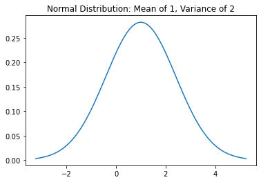

```python
mu = 1
variance = 2
sigma = math.sqrt(variance)
x_norm = np.linspace(mu - 3*sigma, mu + 3*sigma, 1000)
plt.plot(x_norm, stats.norm.pdf(x_norm, mu, sigma))
plt.title("Normal Distribution: Mean of 1, Variance of 2")
plt.show()
```

## Q1 - Estimation by K-NN

### Creating the KNN_Estimator Class

```python
class KNN_Estimator:
    def __init__(self, X, x_norm, K, N):
        self.X = X
        self.x_norm = x_norm
        self.K = K
        self.N = N

    def KNN_Density_Estimation(self):
        densities = np.zeros(self.x_norm.shape)
        # calculate radii and densities
        for i in range(1000):
            radius = np.abs(self.X['x'] - self.x_norm[i]).sort_values()[:self.K+1].max()
            densities[i] = self.K / (2 * radius * self.N)
        return densities
```

### Initialization of Objects and Visualization

There will be 6 objects created, one for each required combination of N and K. Their estimations are plotted with the actual density as well as the N points.

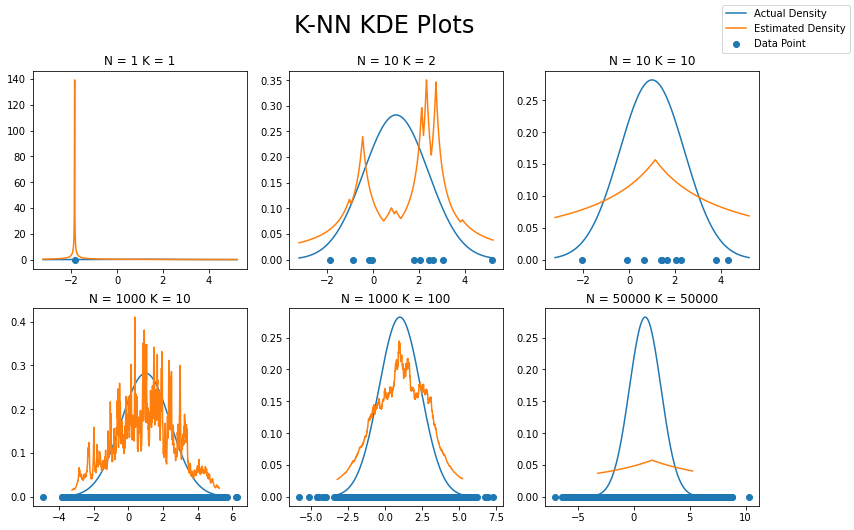

```python
# set up random number gen
seed = 15
rng = np.random.default_rng(seed)

# necessary N and K values
N = [1, 10, 10, 1000, 1000, 50000]
K = [1, 2, 10, 10, 100, 50000]

# produce all knn estimators
knn_estimators = [
    KNN_Estimator(
        pd.DataFrame(rng.normal(1, 2, (N[i], 1)))
            .rename(columns={0:'x'}),
        x_norm, K[i], N[i])
    for i in range(6)
]

# plot figures
fig = plt.figure(figsize=(13, 8))
fig.suptitle('K-NN KDE Plots', fontsize=24)
rows = 2
columns = 3

for i in range(6):
    fig.add_subplot(rows, columns, i + 1)
    densities = knn_estimators[i].KNN_Density_Estimation()
    plt.scatter(knn_estimators[i].X['x'], np.zeros(knn_estimators[i].X['x'].shape))
    plt.plot(x_norm, stats.norm.pdf(x_norm, mu, sigma))
    plt.plot(x_norm, densities)
    plt.title(f"N = {N[i]} K = {K[i]}")

fig.legend(['Actual Density', 'Estimated Density', 'Data Point'])
plt.show()
```

## Q2 - Gaussian KDE

### Creating the G_KDE Class

```python
class G_KDE:
    def __init__(self, X, x_norm, N, sigma):
        self.X = X
        self.x_norm = x_norm
        self.N = N
        self.sigma = sigma

    # returns estimated densities
    def Gaussian_KDE(self):
        densities = np.zeros(x_norm.shape)
        for i in range(1000):
            densities[i] = self.Calc_Gauss_Fhat(self.x_norm[i], self.X['x'], self.N, self.sigma)
        return densities

    # calculates estimated density
    def Calc_Gauss_Fhat(self, x, X_j, N, sigma):
        rho = self.Gaussian_Kernel(x, X_j, sigma)
        return np.sum(rho) / (N * sigma)

    # calculates the gauss kernel
    def Gaussian_Kernel(self, x, X_j, sigma):
        X = np.full(X_j.shape, x)
        frac = 1 / math.sqrt(2 * math.pi)
        exp = np.exp(-0.5 * ((X - X_j) / sigma) ** 2)
        return frac * exp
```

### Initialization of Objects and Visualization

There will be 7 objects created, one for each different N. Their estimations are plotted with the actual density as well as the N points.

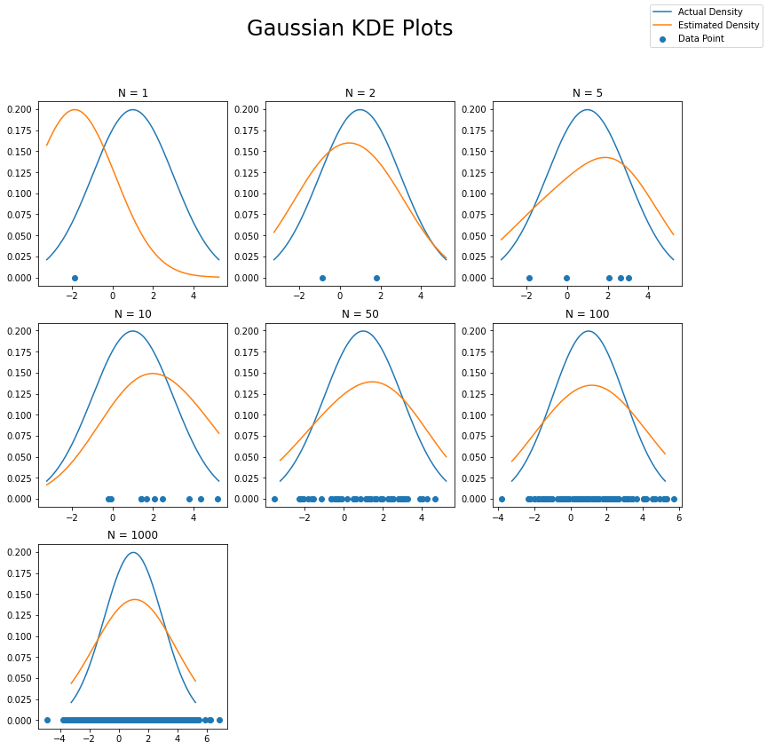

```python
# reset num generator
rng = np.random.default_rng(seed)

# required N and sigma val
N = np.array([1, 2, 5, 10, 50, 100, 1000])
sigma = 2

# create all gauss KDE
gauss_estimators = [
    G_KDE (
        pd.DataFrame(rng.normal(1, 2, (N[i], 1))).rename(columns={0:'x'}),
        x_norm,
        N[i],
        sigma
    )
    for i in range(7)
]

# plot densities
fig = plt.figure(figsize=(13, 13))
fig.suptitle('Gaussian KDE Plots', fontsize=24)
rows = 3
columns = 3

for i in range(7):
    fig.add_subplot(rows, columns, i + 1)
    densities = gauss_estimators[i].Gaussian_KDE()
    plt.scatter(gauss_estimators[i].X['x'], np.zeros(gauss_estimators[i].X['x'].shape))
    plt.plot(x_norm, stats.norm.pdf(x_norm, mu, sigma))
    plt.plot(x_norm, densities)
    plt.title(f"N = {N[i]}")

fig.legend(['Actual Density', 'Estimated Density', 'Data Point'])
plt.show()
```

## Q3 - Histogram Method

### Creating the Histogram Class

```python
class Histogram:
    def __init__(self, X, num_bins):
        self.X = X
        self.h = (X.max() - X.min()) / num_bins
        self.bins = np.arange(X.min(), X.max()+self.h, self.h)
        self.bins[0] -= .0001

    # returns estimated densities of bins
    def calc_densities(self):
        count_in_bins = self.X.groupby(pd.cut(self.X, self.bins)).count()
        return count_in_bins / (self.h * self.X.count())
```

### Initializing Objects

There will be 9 objects created, one for each combination of N and num_bins. Two of the models are printed showing their bin ranges and corresponding densities.

```python
# reset number gen
rng = np.random.default_rng(seed)

# required N and bins
N = [5, 10, 500]
num_bins = [2, 5, 20]

# create all histogram estimators
histograms = [
    [
        Histogram(
            pd.Series(rng.normal(1, 2, (N[j]))),
            num_bins[i])
        for i in range(3)
    ]
    for j in range(3)
]

# print out some of the densities
print("N = 5, Bins = 2 Densities\n")
print(pd.DataFrame(histograms[0][0].calc_densities()).rename(columns={0:'Density'}))
print("\n\nN = 500, Bins = 20 Densities\n")
print(pd.DataFrame(histograms[2][2].calc_densities()).rename(columns={0:'Density'}))
```

```
N = 5, Bins = 2 Densities

                   Density
(-1.862, 0.0947]  0.306672
(0.0947, 2.051]   0.204448


N = 500, Bins = 20 Densities

                   Density
(-5.831, -5.197]  0.003156
(-5.197, -4.564]  0.006313
(-4.564, -3.93]   0.003156
(-3.93, -3.296]   0.003156
(-3.296, -2.663]  0.031563
(-2.663, -2.029]  0.072594
(-2.029, -1.395]  0.047344
(-1.395, -0.762]  0.104157
(-0.762, -0.128]  0.132563
(-0.128, 0.506]   0.160969
(0.506, 1.139]    0.220938
(1.139, 1.773]    0.208313
(1.773, 2.407]    0.167282
(2.407, 3.04]     0.151501
(3.04, 3.674]     0.107313
(3.674, 4.307]    0.066281
(4.307, 4.941]    0.041031
(4.941, 5.575]    0.018938
(5.575, 6.208]    0.022094
(6.208, 6.842]    0.009469
```

### Plotting the Densities

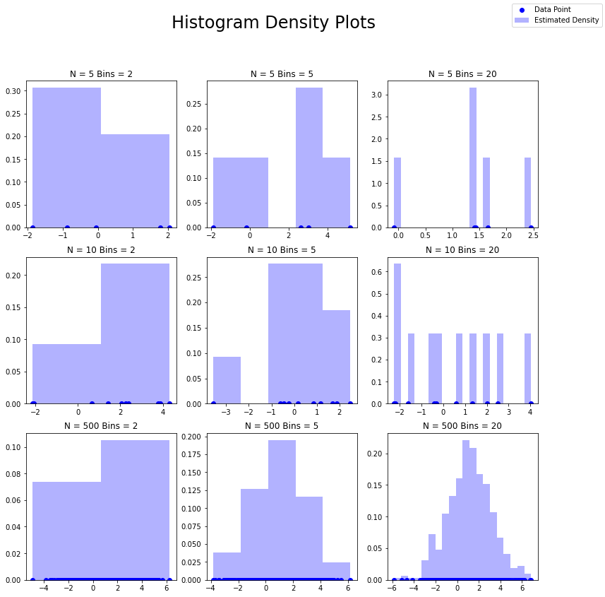

```python
fig = plt.figure(figsize=(13, 13))
fig.suptitle('Histogram Density Plots', fontsize=24)
rows = 3
columns = 3
count = 1

for i in range(3):
    for j in range(3):
        fig.add_subplot(rows, columns, count)
        plt.hist(histograms[i][j].X, histograms[i][j].bins, density=True, color='g', fc=(0, 0, 1, 0.3))
        plt.scatter(histograms[i][j].X, np.zeros(histograms[i][j].X.shape), color='b')
        plt.title(f"N = {N[i]} Bins = {num_bins[j]}")
        count += 1

fig.legend(['Data Point', 'Estimated Density'])
plt.show()
```